# 13-Hypothesis-testing-Part-1

## Hypothesis Testing: Single-Sample Parametric Tests

Author & Instructor: Diana NURBAKOVA, PhD.

```python
%%html
<link rel="stylesheet" type="text/css" href="../styles/styles.css">
```

## Learning Objectives

By the end of this lesson, you will be able to:

- Construct a single-sample parametric test for a population mean, variance and proportion
- Understand $p$-value

```python
import numpy as np
import pandas as pd
import matplotlib.pyplot as plt
import seaborn as sns
from scipy import stats
from mpl_toolkits.mplot3d import Axes3D
import warnings
warnings.filterwarnings('ignore')

# Set style for better-looking plots
plt.style.use('seaborn-v0_8-darkgrid')
sns.set_style("whitegrid")
#sns.set_palette("husl")

# Set random seed for reproducibility
np.random.seed(42)
```

```python
from ipywidgets import interact, IntSlider, FloatSlider, Dropdown
import ipywidgets as widgets
```

```python
#plt.rcParams['font.family'] = ['DejaVu Sans', 'Segoe UI Emoji']
```

```python
import sys
from pathlib import Path
```

```python
# Add the "resources" directory to the path
project_root = Path().resolve()#.parent.parent
resources_path = project_root / 'Course_Materials/resources'
sys.path.insert(0, str(resources_path))
```

```python
from hypothesis_testing import (visualize_hypothesis_types, create_error_matrix, simulate_hypothesis_test_errors,
                                interactive_pvalue_visualization, simulate_pvalue_distribution, visualize_test_statistic_concept)
```

```python
from statsmodels.stats.proportion import proportions_ztest
```

#### 🎯 Today's Challenge: How Real is the Difference?

**Scenario:** You've trained a new image classification model and tested it on 500 images. It correctly classified 471 images (94.2% accuracy).

Your boss says: "Our baseline model has 95% accuracy. Your new model isn't good enough."

You reply: "But maybe I just got unlucky with my test set? With a different 500 images, I might have gotten 95% or higher!"

**The Million Dollar Question:** Is 94.2% statistically different from 95%, or could this difference be explained by random chance?

By the end of this lesson, you'll know *exactly* how to answer this with mathematical certainty.

## What are Null Hypothesis and Alternative Hypothesis?

#### Definition: Hypothesis

A **hypothesis** is a premise/statement that one wishes to test/study/validate (i.e. take a sample, extract information and test it).

⚠️ One of the challenges is to extract a hypothesis from the problem/data: understand *what* is being studied and choose an *appropriate test*

Think of the notion of **Presumption of Innocence**. In a courtroom, we start with: *"The defendant is innocent until proven guilty"*.

In hypothesis testing, we start with: *"The status quo is true until the data proves otherwise"*.

#### Definition: Null Hypothesis (H₀)

**The null hypothesis $H_0$** is the default assumption, the "nothing interesting is happening" position. It's what we assume to be true unless we find strong evidence against it. Usually we consider a currently accepted parameter value (e.g. based on a previous study).

**Examples in ML:**

- H₀: "The model accuracy is 95%" (not better, not worse)
- H₀: "The mean prediction error is 0" (model is unbiased)
- H₀: "The variance of predictions equals the target variance"

#### Definition: Alternative Hypothesis (H₁ or Hₐ)

The **alternative hypothesis** (aka research hypothesis, counter-hypothesis) is what we're trying to find evidence FOR. It's the "something interesting is happening" position. This statement differs from the null hypothesis.

#### Example: Formulating Hypotheses

It is estimated that the coffee machine on the ground floor of the Blaise Pascal building uses 5g of coffee per cup. A maintenance worker claims that the machine no longer uses 5g. Write $H_0$ and $H_1$.

##### Solution

1. Formulate $H_0$

What everyone thinks, i.e. the default assetion is given by "*uses 5g of coffee per cup*".

Hence, the parameter of interest is the *average amount of coffee per cup* and its default, currently accepted value is 5:

$$H_0: \mu = 5g$$

2. Formulate $H_1$

A new statement is given by "*the machine no longer uses 5g*".

Hence: $$H_1: \mu \neq 5$$

> What are the possible outcomes of a test (study, experiment, investigation) of this hypothesis $H_1$?
1. Option 1: **REJECT $H_0$**

We might have enough evidence that $H_0$ is false

2. Option 2: **FAIL TO REJECT $H_0$**

## What is a Statistical Test?

#### Definition: Test Statistic

A **test statistic** is a statistic calculated from sample data and used to make a decision about the outcome of the test.

#### Definition: Statistical Significance

Statistical significance defines the boundary between options (Reject $H_0$ or Fail to Reject $H_0$), enabling us to make a decision.

Suppose we take samples of size 50 and calculate sample means:

- $\bar{X}_{n1} = 5.12g$ Is this close enough to 5g?
- $\bar{X}_{n1} = 5.76g$ Is it close enough to 5g? Is it OK?
- $\bar{X}_{n1} = 7.15g$ Is it far enough from 5g?

#### Definition: Level of Confidence

**Level of confidence** $\beta$ reflects how certain we are of our decision.

#### Definition: Significance Level

**Significance level**, $\alpha = 1 - \beta$, is a risk threshold.

#### Definition: Statistical Test

A **test** is a procedure that allows us to decide whether, based on the observations, we should accept or reject the hypothesis in question.

|  | Parametric Test | Non-Parametric Test |
| --- | --- | --- |
| **Definition** | A hypothesis can be formulated using parameters that our model can estimate | A test independent of any prior data modelling |
| **Examples** | the level of pesticides in a vegetable follows a normal distribution, with mean $\theta$, and the test will be formulated based on the value of $\theta$ | the observations follow the normal distribiton; two variables are correlated, etc. |

#### Example: Formulating Hypotheses 2

According to previous studies, a company produces straws from recycled materials with a diameter of 4 mm. However, technicians are concerned that the machines are not producing straws of this size any more. To test this hypothesis with a confidence level of 99%, they took a sample of size 100. Write $H_0$ and $H_1$.

##### Solution

$$H_0: \mu = 4mm$$ $$H_1: \mu \neq 4mm$$

- Sample size: $n = 100$
- Level of Confidence: $\beta = 0.99$
- Significance Level: $\alpha = 1 - \beta = 1 - 0.99 = 0.01$

#### Example: Formulating Hypotheses 3

Teachers claim that at least 60% of students use their phones during class. One teacher considers this number to be exaggerated and randomly selects 25 students to test his hypothesis with a significance level of 0.02. Write $H_0$ and $H_1$.

##### Solution

Note, here are dealing with *proportions*: "60% of students".

As the default claim is *"at least 60% of students"*:

$$H_0: p \geq 0.6$$

Hence: $$H_1: p < 0.6$$

- Sample size: $n = 25$
- Significance Level: $\alpha = 0.02$
- Level of Confidence: $\beta = 1 - \alpha = 1 - 0.02 = 0.98$

##### Definition: Three Types of Tests based on the H1

**Three Types:**

- **Two-tailed:** H₁: μ ≠ μ₀ (parameter is different)
- **Right-tailed:** H₁: μ > μ₀ (parameter is greater)
- **Left-tailed:** H₁: μ < μ₀ (parameter is smaller)

General workflow can be presented as follows:

[figure not shown]

Choice of test to be conducted with respect to the parameter $\theta$ given the value $\theta_0$:

[figure not shown]

```python
# Interactive widget
test_type_widget = widgets.RadioButtons(
    options=['two-tailed', 'right-tailed', 'left-tailed'],
    description='Test Type:',
    value='two-tailed'
)

alpha_widget = widgets.FloatSlider(
    value=0.05,
    min=0.01,
    max=0.20,
    step=0.01,
    description='α level:',
    continuous_update=False
)

widgets.interactive(visualize_hypothesis_types, test_type=test_type_widget, mu0=widgets.fixed(0), alpha=alpha_widget)
```

```
interactive(children=(RadioButtons(description='Test Type:', options=('two-tailed', 'right-tailed', 'left-tail…
```

#### 💡 Key Insight: Choosing the Right Test Type

- **Two-tailed:** Use when you don't know the direction (e.g., "Is my model's accuracy different from 95%?")
- **Right-tailed:** Use when you care about improvement (e.g., "Is my new model better than 95%?")
- **Left-tailed:** Use when you care about degradation (e.g., "Is the error rate less than 5%?")

**ML Rule of Thumb:** Use two-tailed unless you have a strong directional hypothesis from domain knowledge!

#### 🤖 ML Application Spotlight: Choosing Test Direction

**Scenario 1 - Model Comparison:**

Testing if a new recommendation algorithm is *better* than the current one.

→ Use **right-tailed test**: H₁: μ_new > μ_current

**Scenario 2 - Model Validation:**

Testing if model predictions are *unbiased* (mean error should be 0).

→ Use **two-tailed test**: H₁: μ_error ≠ 0

**Scenario 3 - Production Monitoring:**

Testing if response time has *increased* after deployment.

→ Use **right-tailed test**: H₁: μ_time > baseline

**QUESTIONS**:

> How to test a hypothesis? When do the sample-based results become significant? How to select a threshold at which to reject the null hypothesis?

[figure not shown]

## Type I and Type II Errors

#### Definition: Type I Error (False Positive)

**Type I Error ($\alpha$)**: Rejecting $H_0$ when it's actually true.

*Courtroom Analogy*: Convicting an innocent person

*ML Example*: Concluding your model is better than baseline when it's actually not

**Significance Level $\alpha$**: The maximum probability of Type I error we're willing to accept (typically 0.05 or 0.01)

#### Definition: Type II Error (False Negative)

**Type II Error (β)**: Failing to reject $H_0$ when it's actually false.

*Courtroom Analogy*: Letting a guilty person go free

*ML Example*: Failing to detect that your model is significantly better than baseline

**Power (1-β)**: The probability of correctly rejecting a false $H_0$

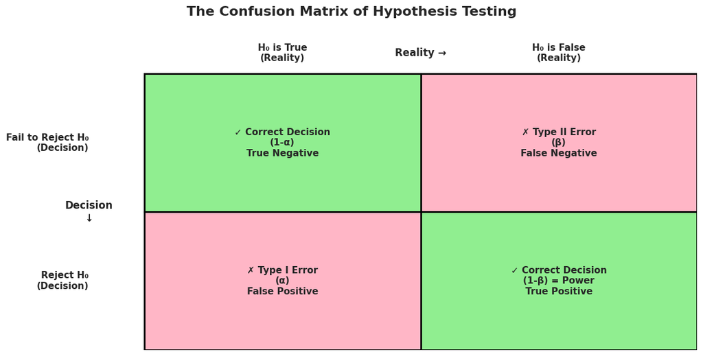

```python
# visualisation
create_error_matrix()
```

```python
# Interactive widgets
true_mean_widget = widgets.FloatSlider(value=0, min=-1, max=1, step=0.1, description='True μ:', continuous_update=False)
test_mean_widget = widgets.FloatSlider(value=0, min=-1, max=1, step=0.1, description='Test μ:', continuous_update=False)
n_samples_widget = widgets.IntSlider(value=30, min=10, max=100, step=10, description='n:', continuous_update=False)
alpha_widget = widgets.FloatSlider(value=0.05, min=0.01, max=0.20, step=0.01, description='α:', continuous_update=False)

widgets.interactive(simulate_hypothesis_test_errors,
                   true_mean=true_mean_widget,
                   test_mean=test_mean_widget,
                   n_samples=n_samples_widget,
                   n_simulations=widgets.fixed(1000),
                   alpha=alpha_widget)
```

```
interactive(children=(FloatSlider(value=0.0, continuous_update=False, description='True μ:', max=1.0, min=-1.0…
```

#### 💡 Key Insights from the Simulation

1. **When H₀ is TRUE** (true_mean = test_mean):
   - Type I error rate ≈ α (by design)
   - We reject H₀ about 5% of the time (when α=0.05) even though it's true
   - This is controlled randomness - we accept this risk
2. **When H₀ is FALSE** (true_mean ≠ test_mean):
   - Power increases as the true difference increases
   - Power increases as sample size increases
   - Power increases as α increases (but this also increases Type I error)
3. **The Tradeoff:** You can't minimize both errors simultaneously
   - Lowering α (stricter) → fewer false positives but more false negatives
   - Raising α (looser) → more false positives but fewer false negatives

#### 🤖 ML Application Spotlight: Type I vs Type II in Production

**Scenario: Medical Diagnosis Model**

*H₀: Patient does not have disease*  
*H₁: Patient has disease*

- **Type I Error:** Diagnosing disease when patient is healthy
  - Consequence: Unnecessary treatment, patient stress, medical costs
- **Type II Error:** Missing disease when patient is sick
  - Consequence: Disease progresses untreated, potentially fatal

**Which is worse?** Usually Type II! We prefer false alarms over missed diagnoses.

**Solution:** Use a higher α (e.g., 0.10 instead of 0.05) or adjust the decision threshold.

**Scenario: Spam Filter**

*H₀: Email is not spam*  
*H₁: Email is spam*

- **Type I Error:** Marking legitimate email as spam
  - Consequence: User misses important messages
- **Type II Error:** Letting spam into inbox
  - Consequence: User sees annoying emails

**Which is worse?** Type I! Missing important emails is worse than seeing spam.

**Solution:** Use a lower α (e.g., 0.01) to be conservative about rejecting H₀.

## Test Statistic

#### Definition: Test Statistic

A **test statistic** is a standardized measure of how far our sample evidence is from what we'd expect under H₀.

$$\text{Test Statistic} = (Observed - Expected) / \text{Standard Error}$$

**Intuition:** It's like a "surprise score" - how many standard errors away from expected is our observation?

- Test statistic near 0 → Sample is consistent with H₀
- Test statistic far from 0 → Sample contradicts H₀

```python
# Interactive widget
observed_widget = widgets.FloatSlider(value=1.5, min=-3, max=3, step=0.1, description='Observed:', continuous_update=False)
h0_widget = widgets.FloatSlider(value=0, min=-2, max=2, step=0.1, description='H₀ mean:', continuous_update=False)
std_widget = widgets.FloatSlider(value=1, min=0.5, max=2, step=0.1, description='Std Dev:', continuous_update=False)
n_widget = widgets.IntSlider(value=30, min=10, max=200, step=10, description='n:', continuous_update=False)

widgets.interactive(visualize_test_statistic_concept,
                   observed_mean=observed_widget,
                   h0_mean=h0_widget,
                   sample_std=std_widget,
                   sample_size=n_widget)
```

```
interactive(children=(FloatSlider(value=1.5, continuous_update=False, description='Observed:', max=3.0, min=-3…
```

## The $p$-Value - Understanding Statistical Significance

#### Definition: P-Value

The **p-value** is the probability of observing a test statistic as extreme as (or more extreme than) the one calculated from your sample data, *assuming H₀ is true*.

**In plain English:** "If H₀ were true, how surprised should we be by what we observed?"

- **Small p-value (< α):** "This would be very surprising if H₀ were true" → Reject H₀
- **Large p-value (≥ α):** "This is not surprising if H₀ were true" → Fail to reject H₀

#### ⚠️ Common Misconceptions About P-Values

**WRONG:** "p-value is the probability that H₀ is true"

**RIGHT:** "p-value is the probability of seeing data this extreme, IF H₀ is true"

**WRONG:** "p = 0.04 means there's a 96% chance H₁ is correct"

**RIGHT:** "p = 0.04 means if H₀ were true, we'd see results this extreme only 4% of the time"

**WRONG:** "p = 0.051 means H₀ is true, p = 0.049 means H₁ is true"

**RIGHT:** "α = 0.05 is an arbitrary threshold; p = 0.051 and p = 0.049 are practically identical"

**WRONG:** "Failing to reject H₀ proves H₀ is true"

**RIGHT:** "Failing to reject H₀ means we don't have enough evidence against it (yet)"

```python
# Interactive widgets
test_stat_widget = widgets.FloatSlider(value=2.5, min=-4, max=4, step=0.1, description='Test Stat:', continuous_update=False)
test_type_widget = widgets.RadioButtons(options=['two-tailed', 'right-tailed', 'left-tailed'],
                                        description='Test Type:', value='two-tailed')
dist_widget = widgets.RadioButtons(options=['z', 't'], description='Distribution:', value='z')

widgets.interactive(interactive_pvalue_visualization,
                   test_statistic=test_stat_widget,
                   test_type=test_type_widget,
                   distribution=dist_widget)
```

```
interactive(children=(FloatSlider(value=2.5, continuous_update=False, description='Test Stat:', max=4.0, min=-…
```

#### 💡 Key Insight: P-Values Under the Null Hypothesis

A fundamental property: **When H₀ is true, p-values follow a Uniform(0,1) distribution**

This means:

- P(p-value < 0.05) = 0.05 when H₀ is true (exactly our Type I error rate)
- P(p-value < 0.01) = 0.01 when H₀ is true
- All p-values between 0 and 1 are equally likely

This is why α directly controls Type I error rate

```python
# Interactive widgets
h0_widget = widgets.RadioButtons(options=[('H₀ is TRUE', True), ('H₀ is FALSE', False)],
                                 description='Truth:', value=True)
effect_widget = widgets.FloatSlider(value=0, min=0, max=1, step=0.1, description='Effect size:',
                                   continuous_update=False)
n_sim_widget = widgets.Dropdown(options=[1000, 5000, 10000], value=10000, description='# Sims:')

widgets.interactive(simulate_pvalue_distribution,
                   h0_true=h0_widget,
                   effect_size=effect_widget,
                   n_simulations=n_sim_widget,
                   sample_size=widgets.fixed(50))
```

```
interactive(children=(RadioButtons(description='Truth:', options=(('H₀ is TRUE', True), ('H₀ is FALSE', False)…
```

> Why do we need $p$-value if we can use Critical Regions to reject the $H_0$?

Because $p$-value allow to select the risk threshold $\alpha$ that is required to define the conditions for rejecting $H_0$.

## Tests for Means

#### T-Test (Unknown Population Variance)

**When to use:** Testing a population mean when σ² is unknown

**Test Statistic:**

$$t = \frac{\bar{X} - \mu_0} {s / \sqrt{n}}$$

**Distribution:** t-distribution with (n-1) degrees of freedom

**Key Difference from z-test:** Uses sample standard deviation (s) instead of population σ, and accounts for this uncertainty with heavier tails

**ML Example:** Testing model performance with limited validation data

**Python Implementation:** [`scipy.stats.ttest_1samp`](https://docs.scipy.org/doc/scipy/reference/generated/scipy.stats.ttest_1samp.html)

[figure not shown]

#### Definition: Critical Region

A **Critical Region** of level $\alpha$ is a rejection region of the null hypothesis. It is a region where $H_1$ is more likely than $H_0$.

[figure not shown]

#### Calculated Example: Model Response Time

**Context:** Your ML model's average prediction time is supposed to be 50ms. After moving to a new server, you measure 25 predictions and get a mean of 53ms with a standard deviation of 8ms.

**Tasks:**

1. Which test should you use (z or t)? Why?
2. Perform the test manually
3. Create a visualization of your results
4. Verify with scipy
5. Calculate a 95% confidence interval for the true mean

```python
# Given data
n = 25
x_bar = 53  # observed mean (ms)
s = 8  # sample standard deviation (ms)
mu0 = 50  # claimed mean (ms)
alpha = 0.05

print("\nGIVEN INFORMATION:")
print("-"*80)
print(f"Sample size: n = {n} predictions")
print(f"Sample mean: x̄ = {x_bar} ms")
print(f"Sample std dev: s = {s} ms")
print(f"Claimed mean: μ₀ = {mu0} ms")
print(f"Significance level: α = {alpha}")
```

```
GIVEN INFORMATION:
--------------------------------------------------------------------------------
Sample size: n = 25 predictions
Sample mean: x̄ = 53 ms
Sample std dev: s = 8 ms
Claimed mean: μ₀ = 50 ms
Significance level: α = 0.05
```

We are testing a mean. We will use t-test.

1. Step 1: Formulate Hypotheses
- Main question: 'Is response time still 50ms, or has it increased after moving servers?'
- Key phrase: 'supposed to be 50ms' → This is our null hypothesis (baseline)
- Observed: 53ms (which is MORE than 50ms) → We're concerned response time might have INCREASED → This suggests a RIGHT-TAILED test

$$H₀: μ = 50 ms \text{ (Response time unchanged)}$$ $$H₁: μ > 50 ms \text{ (Response time increased)}$$

```python
# Calculate the test statistic
# Standard error
se = s / np.sqrt(n)
print(f"\n1. Standard Error:")
print(f"   SE = s / √n")
print(f"      = {s} / √{n}")
print(f"      = {s} / {np.sqrt(n):.4f}")
print(f"      = {se:.4f} ms")

# t-statistic
t_stat = (x_bar - mu0) / se
print(f"\n2. Test Statistic:")
print(f"   t = (x̄ - μ₀) / SE")
print(f"     = ({x_bar} - {mu0}) / {se:.4f}")
print(f"     = {x_bar - mu0} / {se:.4f}")
print(f"     = {t_stat:.4f}")

# Degrees of freedom
df = n - 1
print(f"\n3. Degrees of Freedom:")
print(f"   df = n - 1 = {n} - 1 = {df}")

print(f"\n4. Interpretation:")
print(f"   t = {t_stat:.4f} means the observed mean is {t_stat:.2f} standard")
print(f"   errors ABOVE the claimed value of {mu0} ms")
```

```
1. Standard Error:
   SE = s / √n
      = 8 / √25
      = 8 / 5.0000
      = 1.6000 ms

2. Test Statistic:
   t = (x̄ - μ₀) / SE
     = (53 - 50) / 1.6000
     = 3 / 1.6000
     = 1.8750

3. Degrees of Freedom:
   df = n - 1 = 25 - 1 = 24

4. Interpretation:
   t = 1.8750 means the observed mean is 1.88 standard
   errors ABOVE the claimed value of 50 ms
```

```python
# Critical value (right-tailed)
t_critical = stats.t.ppf(1 - alpha, df)
print(f"\nCritical Value (right-tailed, α = {alpha}):")
print(f"  t_critical = t₍₁₋ₐ, df₎")
print(f"             = t₍{1-alpha}, {df}₎")
print(f"             = {t_critical:.4f}")
```

```
Critical Value (right-tailed, α = 0.05):
  t_critical = t₍₁₋ₐ, df₎
             = t₍0.95, 24₎
             = 1.7109
```

```python
# P-value (right-tailed)
p_value = 1 - stats.t.cdf(t_stat, df)
print(f"\nP-value (right-tailed):")
print(f"  p-value = P(t > {t_stat:.4f} | df = {df})")
print(f"          = {p_value:.6f}")
print()
print(f"  Interpretation: If the true mean is 50ms, the probability of")
print(f"  observing a sample mean of 53ms or higher is {p_value:.4f}")
```

```
P-value (right-tailed):
  p-value = P(t > 1.8750 | df = 24)
          = 0.036506

  Interpretation: If the true mean is 50ms, the probability of
  observing a sample mean of 53ms or higher is 0.0365
```

```python
# Decision
print(f"\nOur results:")
print(f"  t-statistic:   {t_stat:.4f}")
print(f"  Critical value: {t_critical:.4f}")
print(f"  P-value:       {p_value:.6f}")
print(f"  Alpha:         {alpha}")

if t_stat > t_critical:
    print(f"\n✓ Since t = {t_stat:.4f} > t_critical = {t_critical:.4f}")
    print(f"✓ Since p-value = {p_value:.6f} < α = {alpha}")
    print(f"\n→ REJECT H₀")
    print(f"\nConclusion: There IS statistically significant evidence that")
    print(f"the mean response time has INCREASED after moving to the new server.")
else:
    print(f"\n✗ Since t = {t_stat:.4f} ≤ t_critical = {t_critical:.4f}")
    print(f"✗ Since p-value = {p_value:.6f} ≥ α = {alpha}")
    print(f"\n→ FAIL TO REJECT H₀")
    print(f"\nConclusion: There is NOT sufficient evidence that the mean")
    print(f"response time has increased. The observed 53ms could reasonably")
    print(f"occur by chance if the true mean is still 50ms.")
```

```
Our results:
  t-statistic:   1.8750
  Critical value: 1.7109
  P-value:       0.036506
  Alpha:         0.05

✓ Since t = 1.8750 > t_critical = 1.7109
✓ Since p-value = 0.036506 < α = 0.05

→ REJECT H₀

Conclusion: There IS statistically significant evidence that
the mean response time has INCREASED after moving to the new server.
```

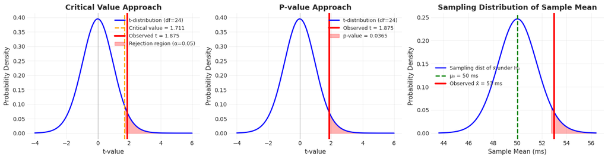

```python
# visualisation
fig, axes = plt.subplots(1, 3, figsize=(15, 4))

# Plot 1: t-distribution with test statistic
x_t = np.linspace(-4, 6, 1000)
y_t = stats.t.pdf(x_t, df)

axes[0].plot(x_t, y_t, 'b-', linewidth=2, label=f't-distribution (df={df})')
axes[0].axvline(0, color='gray', linestyle='-', linewidth=1, alpha=0.5)
axes[0].axvline(t_critical, color='orange', linestyle='--', linewidth=2,
                  label=f'Critical value = {t_critical:.3f}')
axes[0].axvline(t_stat, color='red', linestyle='-', linewidth=3,
                  label=f'Observed t = {t_stat:.3f}')

# Shade rejection region
axes[0].fill_between(x_t[x_t >= t_critical], 0, y_t[x_t >= t_critical],
                       alpha=0.3, color='red', label=f'Rejection region (α={alpha})')

axes[0].set_xlabel('t-value', fontsize=11)
axes[0].set_ylabel('Probability Density', fontsize=11)
axes[0].set_title('Critical Value Approach', fontsize=13, fontweight='bold')
axes[0].legend(fontsize=9)
axes[0].grid(True, alpha=0.3)

# Plot 2: P-value visualization
axes[ 1].plot(x_t, y_t, 'b-', linewidth=2, label=f't-distribution (df={df})')
axes[ 1].axvline(0, color='gray', linestyle='-', linewidth=1, alpha=0.5)
axes[ 1].axvline(t_stat, color='red', linestyle='-', linewidth=3,
                  label=f'Observed t = {t_stat:.3f}')

# Shade p-value area
axes[1].fill_between(x_t[x_t >= t_stat], 0, y_t[x_t >= t_stat],
                       alpha=0.3, color='red', label=f'p-value = {p_value:.4f}')

axes[1].set_xlabel('t-value', fontsize=11)
axes[1].set_ylabel('Probability Density', fontsize=11)
axes[1].set_title('P-value Approach', fontsize=13, fontweight='bold')
axes[1].legend(fontsize=9)
axes[1].grid(True, alpha=0.3)

# Plot 3: Sampling distribution of x̄
x_means = np.linspace(mu0 - 4*se, mu0 + 4*se, 1000)
y_means = stats.t.pdf((x_means - mu0) / se, df) / se

axes[2].plot(x_means, y_means, 'b-', linewidth=2,
               label=f'Sampling dist of x̄ under H₀')
axes[2].axvline(mu0, color='green', linestyle='--', linewidth=2,
                  label=f'μ₀ = {mu0} ms')
axes[2].axvline(x_bar, color='red', linestyle='-', linewidth=3,
                  label=f'Observed x̄ = {x_bar} ms')

# Shade rejection region in terms of x̄
reject_threshold = mu0 + t_critical * se
axes[2].fill_between(x_means[x_means >= reject_threshold], 0,
                       y_means[x_means >= reject_threshold],
                       alpha=0.3, color='red')

axes[2].set_xlabel('Sample Mean (ms)', fontsize=11)
axes[2].set_ylabel('Probability Density', fontsize=11)
axes[2].set_title('Sampling Distribution of Sample Mean', fontsize=13, fontweight='bold')
axes[2].legend(fontsize=9)
axes[2].grid(True, alpha=0.3)

plt.tight_layout()
plt.show()
```

To verify with python, we can use [`scipy.stats.ttest_1samp`](https://docs.scipy.org/doc/scipy/reference/generated/scipy.stats.ttest_1samp.html):

```python
# python verification
# Generate data: we need n=25 values with mean≈53 and std≈8
np.random.seed(42)
# Start with normal distribution
sample_data = np.random.normal(x_bar, s, n)
# Adjust to match exactly
sample_data = sample_data - sample_data.mean() + x_bar
sample_data = sample_data / sample_data.std(ddof=1) * s

# Perform t-test
t_scipy, p_scipy_two = stats.ttest_1samp(sample_data, mu0)
p_scipy_right = p_scipy_two / 2 if t_scipy > 0 else 1 - p_scipy_two / 2

print("Results:")
print(f"  t-statistic:        {t_scipy:.6f}")
print(f"  p-value (two-tail): {p_scipy_two:.6f}")
print(f"  p-value (right-tail): {p_scipy_right:.6f}")
```

```
Results:
  t-statistic:        3.379548
  p-value (two-tail): 0.002479
  p-value (right-tail): 0.001240
```

```python
# For 95% CI, we need two-tailed critical value
confidence_level = 0.95
alpha_ci = 1 - confidence_level
t_critical_ci = stats.t.ppf(1 - alpha_ci/2, df)

print(f"\n1. Confidence level: {confidence_level*100:.0f}%")
print(f"   → α for CI = {alpha_ci}")
print(f"   → α/2 = {alpha_ci/2}")
```

```
1. Confidence level: 95%
   → α for CI = 0.050000000000000044
   → α/2 = 0.025000000000000022
```

```python
print(f"\n2. Critical value (two-tailed):")
print(f"   t₍₁₋ₐ/₂, df₎ = t₍{1-alpha_ci/2}, {df}₎")
print(f"                = {t_critical_ci:.4f}")
```

```
2. Critical value (two-tailed):
   t₍₁₋ₐ/₂, df₎ = t₍0.975, 24₎
                = 2.0639
```

```python
print(f"\n3. Margin of error:")
margin = t_critical_ci * se
print(f"   ME = t_critical × SE")
print(f"      = {t_critical_ci:.4f} × {se:.4f}")
print(f"      = {margin:.4f} ms")
```

```
3. Margin of error:
   ME = t_critical × SE
      = 2.0639 × 1.6000
      = 3.3022 ms
```

```python
print(f"\n4. Confidence interval:")
ci_lower = x_bar - margin
ci_upper = x_bar + margin
print(f"   CI = x̄ ± ME")
print(f"      = {x_bar} ± {margin:.4f}")
print(f"      = [{ci_lower:.4f}, {ci_upper:.4f}] ms")
```

```
4. Confidence interval:
   CI = x̄ ± ME
      = 53 ± 3.3022
      = [49.6978, 56.3022] ms
```

```python
# interpretation
print(f"\nWe are 95% confident that the true mean response time")
print(f"is between {ci_lower:.2f} ms and {ci_upper:.2f} ms.")
```

```
We are 95% confident that the true mean response time
is between 49.70 ms and 56.30 ms.
```

```python
print("Key observations:")
if ci_lower > mu0:
    print(f"  ✓ The ENTIRE interval is above {mu0} ms")
    print(f"    → Strong evidence that response time has increased")
elif ci_upper < mu0:
    print(f"  ✓ The ENTIRE interval is below {mu0} ms")
    print(f"    → Strong evidence that response time has decreased")
else:
    print(f"  ⚠ The interval CONTAINS {mu0} ms")
    print(f"    → Cannot confidently say if response time changed")
    print(f"    → Consistent with hypothesis test result")
```

```
Key observations:
  ⚠ The interval CONTAINS 50 ms
    → Cannot confidently say if response time changed
    → Consistent with hypothesis test result
```

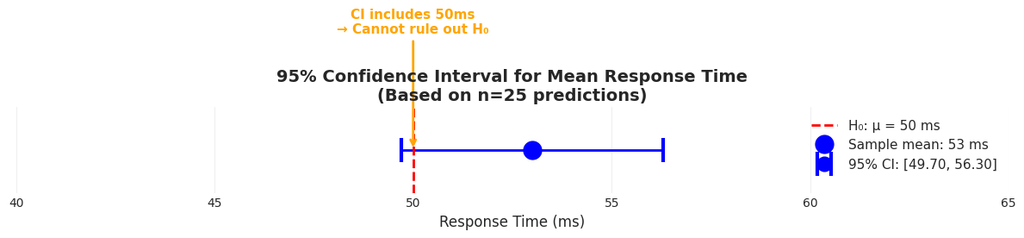

```python
# Visualize CI
fig, ax = plt.subplots(1, 1, figsize=(12, 6))

# Plot the CI
ax.errorbar(x_bar, 0, xerr=margin, fmt='o', markersize=12, capsize=10, capthick=3,
           color='blue', ecolor='blue', linewidth=2, label=f'95% CI: [{ci_lower:.2f}, {ci_upper:.2f}]')

# Add reference line at mu0
ax.axvline(mu0, color='red', linestyle='--', linewidth=2, label=f'H₀: μ = {mu0} ms')

# Add point estimate
ax.plot(x_bar, 0, 'bo', markersize=15, label=f'Sample mean: {x_bar} ms')

ax.set_xlabel('Response Time (ms)', fontsize=12)
ax.set_yticks([])
ax.set_title(f'95% Confidence Interval for Mean Response Time\n(Based on n={n} predictions)',
            fontsize=14, fontweight='bold')
ax.legend(fontsize=11, loc='upper right')
ax.grid(True, alpha=0.3, axis='x')
ax.set_xlim(40, 65)

# Add annotation
if ci_lower > mu0:
    ax.annotate('Entire CI > 50ms\n→ Strong evidence of increase',
               xy=(x_bar, 0), xytext=(x_bar, 0.15),
               arrowprops=dict(arrowstyle='->', color='green', lw=2),
               fontsize=11, color='green', fontweight='bold',
               ha='center')
else:
    ax.annotate('CI includes 50ms\n→ Cannot rule out H₀',
               xy=(mu0, 0), xytext=(mu0, 0.15),
               arrowprops=dict(arrowstyle='->', color='orange', lw=2),
               fontsize=11, color='orange', fontweight='bold',
               ha='center')

plt.tight_layout()
plt.show()
```

```python
# Python verification of CI
ci_scipy = stats.t.interval(confidence_level, df, loc=x_bar, scale=se)
print(f"Results: [{ci_scipy[0]:.4f}, {ci_scipy[1]:.4f}]")
```

```
Results: [49.6978, 56.3022]
```

```python
# SUMMARY
print(f"\nStatistical Results:")
print(f"  • Sample: n={n}, mean={x_bar}ms, SD={s}ms")
print(f"  • Test: t({df}) = {t_stat:.3f}, p = {p_value:.4f}")
if p_value < 0.05:
    print(f"  • Conclusion: SIGNIFICANT increase (p < 0.05)")
else:
    print(f"  • Conclusion: NOT significant (p ≥ 0.05)")
print(f"  • 95% CI: [{ci_lower:.2f}, {ci_upper:.2f}] ms")

print(f"\nPractical Implications:")
print(f"  • Expected: 50ms")
print(f"  • Observed: 53ms (+{x_bar-mu0}ms = +{((x_bar-mu0)/mu0)*100:.0f}% increase)")
print(f"  • Best estimate range: {ci_lower:.1f} to {ci_upper:.1f} ms")

if p_value < 0.05:
    print(f"\nRECOMMENDATION:")
    print(f"  • The {((x_bar-mu0)/mu0)*100:.0f}% increase IS statistically significant")
    print(f"  • Investigate server performance:")
    print(f"    - Check server resources (CPU, memory, network)")
    print(f"    - Compare server specifications")
    print(f"    - Look for configuration differences")
    print(f"  • Consider if +3ms is practically significant for your application")
    print(f"    - For real-time apps: may be problematic")
    print(f"    - For batch processing: likely acceptable")
else:
    print(f"\nRECOMMENDATION:")
    print(f"  • The {((x_bar-mu0)/mu0)*100:.0f}% increase is NOT statistically significant")
    print(f"  • Variation could be due to random chance")
    print(f"  • Continue monitoring, collect more data if concerned")
    print(f"  • Consider testing with larger sample size for more precision")
```

```
Statistical Results:
  • Sample: n=25, mean=53ms, SD=8ms
  • Test: t(24) = 1.875, p = 0.0365
  • Conclusion: SIGNIFICANT increase (p < 0.05)
  • 95% CI: [49.70, 56.30] ms

Practical Implications:
  • Expected: 50ms
  • Observed: 53ms (+3ms = +6% increase)
  • Best estimate range: 49.7 to 56.3 ms

RECOMMENDATION:
  • The 6% increase IS statistically significant
  • Investigate server performance:
    - Check server resources (CPU, memory, network)
    - Compare server specifications
    - Look for configuration differences
  • Consider if +3ms is practically significant for your application
    - For real-time apps: may be problematic
    - For batch processing: likely acceptable
```

## Tests for Variance

When testing variance, we're asking questions like:

- Is the variability in model predictions acceptable?
- Has the process variability changed after an update?
- Does population variance equal a specific value?

*Note:* Variance tests are SENSITIVE to normality assumption

#### Chi-Square Test

**When to use:** Testing a population variance

**Test Statistic:**

$$K = \frac{(n - 1)\times s^2} {\sigma_0^2} = \frac{\nu\times s^2} {\sigma_0^2} \sim \chi^2(\nu = n-1)$$

**Distribution**: $\chi^2$-distribution with (n-1) degrees of freedom

**Assumptions:**

- Data must be normally distributed
- Very sensitive to non-normality
- Independent observations
- Random sample

**Python Implementation:** no direct implementation

[figure not shown]

#### Calculated Example: Right-Tailed Test for Variance

Scenario: You have an ML model that should have prediction errors with standard deviation σ = 5. After retraining, you collect n=30 predictions and find s = 6.2. Has the variability increased?

- H₀: σ² = 25 (σ = 5)
- H₁: σ² > 25 (right-tailed: testing if MORE variable)
- α = 0.05

```python
# Given data
n = 30
s = 6.2
s_squared = s**2
sigma0 = 5
sigma0_squared = sigma0**2
alpha = 0.05

print(f"Given:")
print(f"  Sample size: n = {n}")
print(f"  Sample std dev: s = {s}")
print(f"  Sample variance: s² = {s_squared:.2f}")
print(f"  Hypothesized std dev: σ₀ = {sigma0}")
print(f"  Hypothesized variance: σ₀² = {sigma0_squared}")
```

```
Given:
  Sample size: n = 30
  Sample std dev: s = 6.2
  Sample variance: s² = 38.44
  Hypothesized std dev: σ₀ = 5
  Hypothesized variance: σ₀² = 25
```

```python
# Calculate Test Statistic
df = n - 1
chi_squared = (n - 1) * s_squared / sigma0_squared

print(f"\nStep 1: Degrees of freedom")
print(f"  df = n - 1 = {n} - 1 = {df}")

print(f"\nStep 2: Calculate test statistic")
print(f"  χ² = (n-1) × s² / σ₀²")
print(f"     = {n-1} × {s_squared:.2f} / {sigma0_squared}")
print(f"     = {(n-1) * s_squared:.2f} / {sigma0_squared}")
print(f"     = {chi_squared:.4f}")
```

```
Step 1: Degrees of freedom
  df = n - 1 = 30 - 1 = 29

Step 2: Calculate test statistic
  χ² = (n-1) × s² / σ₀²
     = 29 × 38.44 / 25
     = 1114.76 / 25
     = 44.5904
```

```python
# Critical value for right-tailed test
chi_critical = stats.chi2.ppf(1 - alpha, df)

print(f"\nStep 3: Critical value (right-tailed, α={alpha})")
print(f"  χ²_critical = χ²_{1-alpha}({df}) = {chi_critical:.4f}")
```

```
Step 3: Critical value (right-tailed, α=0.05)
  χ²_critical = χ²_0.95(29) = 42.5570
```

```python
# P-value
p_value = 1 - stats.chi2.cdf(chi_squared, df)

print(f"\nStep 4: P-value")
print(f"  p-value = P(χ² > {chi_squared:.4f} | df={df})")
print(f"          = {p_value:.6f}")
```

```
Step 4: P-value
  p-value = P(χ² > 44.5904 | df=29)
          = 0.032233
```

```python
# Decision
print(f"\nStep 5: Decision at α = {alpha}")
print(f"  Critical value method:")
if chi_squared > chi_critical:
    print(f"    χ² = {chi_squared:.4f} > {chi_critical:.4f} → REJECT H₀")
else:
    print(f"    χ² = {chi_squared:.4f} ≤ {chi_critical:.4f} → FAIL TO REJECT H₀")

print(f"\n  P-value method:")
if p_value < alpha:
    print(f"    p = {p_value:.6f} < {alpha} → REJECT H₀")
else:
    print(f"    p = {p_value:.6f} ≥ {alpha} → FAIL TO REJECT H₀")
```

```
Step 5: Decision at α = 0.05
  Critical value method:
    χ² = 44.5904 > 42.5570 → REJECT H₀

  P-value method:
    p = 0.032233 < 0.05 → REJECT H₀
```

```python
# Interpretation
print(f"\nStep 6: Interpretation")
if p_value < alpha:
    print(f"  ✓ There is significant evidence that the variability has INCREASED.")
    print(f"  ✓ The model predictions are now more variable than before.")
    print(f"  ✓ Recommendation: Investigate what changed in the model.")
else:
    print(f"  ✓ There is insufficient evidence that variability has increased.")
    print(f"  ✓ The observed variability (s={s}) could be due to chance.")
    print(f"  ✓ The model consistency appears acceptable.")
```

```
Step 6: Interpretation
  ✓ There is significant evidence that the variability has INCREASED.
  ✓ The model predictions are now more variable than before.
  ✓ Recommendation: Investigate what changed in the model.
```

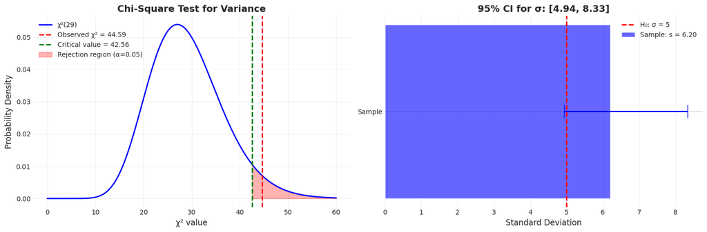

```python
# Visualize
fig, axes = plt.subplots(1, 2, figsize=(15, 5))

# Plot 1: Chi-square distribution
x = np.linspace(0, 60, 1000)
y = stats.chi2.pdf(x, df)

axes[0].plot(x, y, 'b-', linewidth=2, label=f'χ²({df})')
axes[0].axvline(chi_squared, color='red', linestyle='--', linewidth=2,
               label=f'Observed χ² = {chi_squared:.2f}')
axes[0].axvline(chi_critical, color='green', linestyle='--', linewidth=2,
               label=f'Critical value = {chi_critical:.2f}')

# Shade rejection region
x_reject = x[x >= chi_critical]
y_reject = stats.chi2.pdf(x_reject, df)
axes[0].fill_between(x_reject, 0, y_reject, alpha=0.3, color='red',
                     label=f'Rejection region (α={alpha})')

axes[0].set_xlabel('χ² value', fontsize=12)
axes[0].set_ylabel('Probability Density', fontsize=12)
axes[0].set_title('Chi-Square Test for Variance', fontsize=14, fontweight='bold')
axes[0].legend(fontsize=10)
axes[0].grid(True, alpha=0.3)

# Plot 2: Confidence interval for variance
from scipy.stats import chi2

# Confidence interval for σ²
chi2_lower = chi2.ppf(alpha/2, df)
chi2_upper = chi2.ppf(1 - alpha/2, df)

var_ci_lower = (n-1) * s_squared / chi2_upper
var_ci_upper = (n-1) * s_squared / chi2_lower

# For standard deviation
std_ci_lower = np.sqrt(var_ci_lower)
std_ci_upper = np.sqrt(var_ci_upper)

axes[1].barh(['Sample'], [s], color='blue', alpha=0.6, label=f'Sample: s = {s:.2f}')
axes[1].errorbar([s], ['Sample'], xerr=[[s - std_ci_lower], [std_ci_upper - s]],
                fmt='none', color='blue', linewidth=2, capsize=10)
axes[1].axvline(sigma0, color='red', linestyle='--', linewidth=2,
               label=f'H₀: σ = {sigma0}')

axes[1].set_xlabel('Standard Deviation', fontsize=12)
axes[1].set_title(f'95% CI for σ: [{std_ci_lower:.2f}, {std_ci_upper:.2f}]',
                 fontsize=14, fontweight='bold')
axes[1].legend(fontsize=10)
axes[1].grid(True, alpha=0.3, axis='x')

if sigma0 < std_ci_lower or sigma0 > std_ci_upper:
    axes[1].text(sigma0, 0.5, 'Outside CI\n→ Reject H₀',
                ha='center', fontsize=10, color='red', fontweight='bold',
                bbox=dict(boxstyle='round', facecolor='white', edgecolor='red', linewidth=2))

plt.tight_layout()
plt.show()
```

## Tests for Proportion

When testing proportions, we're asking questions like:

- Is the model accuracy equal to a target value?
- Did the click-through rate improve after the update?

*Note*: Proportions involve BINARY outcomes: success/failure, yes/no, 0/1, click/no-click

#### Z-Test (Normal Approximation)

**When to use:** Testing a population proportion for large samples:

- $np_0 \geq 10$
- $n(1 - p_0) \geq 10$

**Test Statistic:**

$$z = \frac{\hat{p} - p_0}{SE} = \frac{\hat{p} - p_0}{\sqrt{p_0(1-p_0)/n}} \sim N(0,1)$$

**Distribution:** Standard Normal Distribution (approximation)

**Python Implementation:** `statsmodels.stats.proportion.proportions_ztest()` with the parameter `prop_var=p₀`

*Note*: For hypothesis testing, ALWAYS use p₀ in SE, not p̂:

- ✓ Correct: $SE = \sqrt{p₀(1-p₀)/n}$
- ✗ Incorrect: $SE = \sqrt{p̂(1-p̂)/n}$ ← This is for confidence intervals!

[figure not shown]

#### Calculated Example: Left-Tailed Test for Proportion

Scenario: Your image classification model is supposed to achieve 95% accuracy. You test it on 500 new images and it correctly classifies 471.

Question: Has the accuracy decreased?

- H₀: p = 0.95 (accuracy is 95%)
- H₁: p < 0.95 (accuracy is less than 95%) [LEFT-TAILED]
- α = 0.05

```python
# Given data
n = 500
successes = 471
p0 = 0.95
p_hat = successes / n
alpha = 0.05

print(f"Given:")
print(f"  Sample size: n = {n}")
print(f"  Correct classifications: {successes}")
print(f"  Sample proportion: p̂ = {successes}/{n} = {p_hat:.4f}")
print(f"  Null hypothesis: p₀ = {p0}")
```

```
Given:
  Sample size: n = 500
  Correct classifications: 471
  Sample proportion: p̂ = 471/500 = 0.9420
  Null hypothesis: p₀ = 0.95
```

```python
# Check assumptions
np0 = n * p0
n_1mp0 = n * (1 - p0)

print("STEP 1: CHECK ASSUMPTIONS")
print(f"\nFor normal approximation to be valid:")
print(f"  np₀ = {n} × {p0} = {np0:.1f} ≥ 10? {'✓ YES' if np0 >= 10 else '✗ NO'}")
print(f"  n(1-p₀) = {n} × {1-p0} = {n_1mp0:.1f} ≥ 10? {'✓ YES' if n_1mp0 >= 10 else '✗ NO'}")

if np0 >= 10 and n_1mp0 >= 10:
    print(f"\n✓ Normal approximation is valid")
    print(f"✓ Can use z-test")
else:
    print(f"\n⚠ Normal approximation may be questionable")
    print(f"⚠ Should use exact binomial test")
```

```
STEP 1: CHECK ASSUMPTIONS

For normal approximation to be valid:
  np₀ = 500 × 0.95 = 475.0 ≥ 10? ✓ YES
  n(1-p₀) = 500 × 0.050000000000000044 = 25.0 ≥ 10? ✓ YES

✓ Normal approximation is valid
✓ Can use z-test
```

```python
# z-test calculation
se = np.sqrt(p0 * (1 - p0) / n)
z_stat = (p_hat - p0) / se
p_value_z = stats.norm.cdf(z_stat)  # Left-tailed
```

```python
print(f"\nStep 1: Standard Error (using p₀)")
print(f"  SE = √[p₀(1-p₀)/n]")
print(f"     = √[{p0} × {1-p0} / {n}]")
print(f"     = √{p0 * (1-p0) / n:.8f}")
print(f"     = {se:.8f}")
```

```
Step 1: Standard Error (using p₀)
  SE = √[p₀(1-p₀)/n]
     = √[0.95 × 0.050000000000000044 / 500]
     = √0.00009500
     = 0.00974679
```

```python
print(f"\nStep 2: Z-statistic")
print(f"  z = (p̂ - p₀) / SE")
print(f"    = ({p_hat:.4f} - {p0}) / {se:.8f}")
print(f"    = {p_hat - p0:.4f} / {se:.8f}")
print(f"    = {z_stat:.8f}")
```

```
Step 2: Z-statistic
  z = (p̂ - p₀) / SE
    = (0.9420 - 0.95) / 0.00974679
    = -0.0080 / 0.00974679
    = -0.82078268
```

```python
print(f"\nStep 3: P-value (LEFT-TAILED)")
print(f"  p-value = P(Z ≤ {z_stat:.4f})")
print(f"          = Φ({z_stat:.4f})")
print(f"          = {p_value_z:.8f}")
```

```
Step 3: P-value (LEFT-TAILED)
  p-value = P(Z ≤ -0.8208)
          = Φ(-0.8208)
          = 0.20588503
```

```python
# Critical value
z_critical = stats.norm.ppf(alpha)
print(f"\nStep 4: Critical value (α = {alpha})")
print(f"  z_critical = z_{alpha} = {z_critical:.4f}")
```

```
Step 4: Critical value (α = 0.05)
  z_critical = z_0.05 = -1.6449
```

```python
print(f"\nStep 5: Decision")
print(f"  Critical value method:")
if z_stat < z_critical:
    print(f"    z = {z_stat:.4f} < {z_critical:.4f} → REJECT H₀")
else:
    print(f"    z = {z_stat:.4f} ≥ {z_critical:.4f} → FAIL TO REJECT H₀")
```

```
Step 5: Decision
  Critical value method:
    z = -0.8208 ≥ -1.6449 → FAIL TO REJECT H₀
```

```python
print(f"\n  P-value method:")
if p_value_z < alpha:
    print(f"    p = {p_value_z:.6f} < {alpha} → REJECT H₀")
else:
    print(f"    p = {p_value_z:.6f} ≥ {alpha} → FAIL TO REJECT H₀")
```

```
  P-value method:
    p = 0.205885 ≥ 0.05 → FAIL TO REJECT H₀
```

```python
from statsmodels.stats.proportion import proportions_ztest

z_sm_correct, p_sm_correct = proportions_ztest(
    count=successes,
    nobs=n,
    value=p0,
    alternative='smaller',  # left-tailed
    prop_var=p0  # ← Use null hypothesis value
)

print(f"""Results:
  z = {z_sm_correct:.8f}
  p-value = {p_sm_correct:.8f}
""")
```

```
Results:
  z = -0.82078268
  p-value = 0.20588503
```

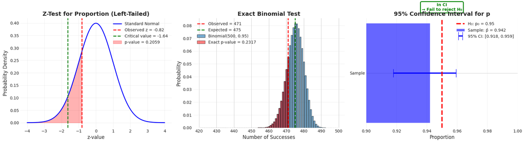

```python
from statsmodels.stats.proportion import proportions_ztest, proportion_confint
# Visualize

# Exact binomial test
p_value_exact = stats.binomtest(k=successes, n=n, p=p0, alternative='less')

fig, axes = plt.subplots(1, 3, figsize=(18, 5))

# Plot 1: Standard normal distribution with z-test
x = np.linspace(-4, 4, 1000)
y = stats.norm.pdf(x)

axes[0].plot(x, y, 'b-', linewidth=2, label='Standard Normal')
axes[0].axvline(z_stat, color='red', linestyle='--', linewidth=2,
               label=f'Observed z = {z_stat:.2f}')
axes[0].axvline(z_critical, color='green', linestyle='--', linewidth=2,
               label=f'Critical value = {z_critical:.2f}')

# Shade p-value area (left tail)
x_pvalue = x[x <= z_stat]
y_pvalue = stats.norm.pdf(x_pvalue)
axes[0].fill_between(x_pvalue, 0, y_pvalue, alpha=0.3, color='red',
                     label=f'p-value = {p_value_z:.4f}')

axes[0].set_xlabel('z-value', fontsize=12)
axes[0].set_ylabel('Probability Density', fontsize=12)
axes[0].set_title('Z-Test for Proportion (Left-Tailed)', fontsize=14, fontweight='bold')
axes[0].legend(fontsize=10)
axes[0].grid(True, alpha=0.3)

# Plot 2: Binomial distribution
x_binom = np.arange(max(0, successes - 50), min(n, successes + 50))
y_binom = stats.binom.pmf(x_binom, n, p0)

axes[1].bar(x_binom, y_binom, alpha=0.6, edgecolor='black', label=f'Binomial({n}, {p0})')
axes[1].axvline(successes, color='red', linestyle='--', linewidth=2,
               label=f'Observed = {successes}')
axes[1].axvline(n * p0, color='green', linestyle='--', linewidth=2,
               label=f'Expected = {n*p0:.0f}')

# Shade p-value area
x_tail = x_binom[x_binom <= successes]
y_tail = stats.binom.pmf(x_tail, n, p0)
axes[1].bar(x_tail, y_tail, alpha=0.5, color='red', edgecolor='black',
           label=f'Exact p-value = {p_value_exact.pvalue:.4f}')

axes[1].set_xlabel('Number of Successes', fontsize=12)
axes[1].set_ylabel('Probability', fontsize=12)
axes[1].set_title('Exact Binomial Test', fontsize=14, fontweight='bold')
axes[1].legend(fontsize=10)
axes[1].grid(True, alpha=0.3, axis='y')

# Plot 3: Confidence interval
ci_lower, ci_upper = proportion_confint(successes, n, alpha=0.05, method='wilson')

axes[2].barh(['Sample'], [p_hat], color='blue', alpha=0.6, label=f'Sample: p̂ = {p_hat:.3f}')
axes[2].errorbar([p_hat], ['Sample'], xerr=[[p_hat - ci_lower], [ci_upper - p_hat]],
                fmt='none', color='blue', linewidth=3, capsize=10,
                label=f'95% CI: [{ci_lower:.3f}, {ci_upper:.3f}]')
axes[2].axvline(p0, color='red', linestyle='--', linewidth=3,
               label=f'H₀: p₀ = {p0}')

# Check if p0 is in CI
if p0 < ci_lower:
    axes[2].text(p0, 0.5, 'Below CI\n→ Reject H₀',
                ha='center', fontsize=10, color='red', fontweight='bold',
                bbox=dict(boxstyle='round', facecolor='white', edgecolor='red', linewidth=2))
elif p0 > ci_upper:
    axes[2].text(p0, 0.5, 'Above CI\n→ Reject H₀',
                ha='center', fontsize=10, color='red', fontweight='bold',
                bbox=dict(boxstyle='round', facecolor='white', edgecolor='red', linewidth=2))
else:
    axes[2].text(p0, 0.5, 'In CI\n→ Fail to reject H₀',
                ha='center', fontsize=10, color='green', fontweight='bold',
                bbox=dict(boxstyle='round', facecolor='white', edgecolor='green', linewidth=2))

axes[2].set_xlabel('Proportion', fontsize=12)
axes[2].set_title('95% Confidence Interval for p', fontsize=14, fontweight='bold')
axes[2].legend(fontsize=10)
axes[2].grid(True, alpha=0.3, axis='x')
axes[2].set_xlim(0.9, 1.0)

plt.tight_layout()
plt.show()
```

```python
if p_value_exact.pvalue < alpha:
    print(f"""
✓ Decision: REJECT H₀ (using exact test, p = {p_value_exact.pvalue:.6f} < 0.05)

Conclusion:
  • The model accuracy ({p_hat*100:.1f}%) is significantly lower than
    the target (95%)
  • This is not just random variation
  • The accuracy has genuinely decreased

Recommendation:
  • Investigate what changed in the model
  • Check if the test data is different
  • Consider retraining or adjusting the model
""")
else:
    print(f"""
✓ Decision: FAIL TO REJECT H₀ (using exact test, p = {p_value_exact.pvalue:.6f} ≥ 0.05)

Conclusion:
  • The observed accuracy ({p_hat*100:.1f}%) is not significantly
    different from the target (95%)
  • The difference could be due to random variation
  • No strong evidence that accuracy has decreased

Recommendation:
  • The model performance appears acceptable
  • Continue monitoring with more data
  • The 95% CI is [{ci_lower*100:.1f}%, {ci_upper*100:.1f}%]
""")
```

```
✓ Decision: FAIL TO REJECT H₀ (using exact test, p = 0.231678 ≥ 0.05)

Conclusion:
  • The observed accuracy (94.2%) is not significantly
    different from the target (95%)
  • The difference could be due to random variation
  • No strong evidence that accuracy has decreased

Recommendation:
  • The model performance appears acceptable
  • Continue monitoring with more data
  • The 95% CI is [91.8%, 95.9%]
```

## Application: Hypothesis Test Workflow

#### 🤖 ML Application: A/B Testing for Recommendation System

**Business Context:** You've developed a new recommendation algorithm for an e-commerce platform. The current algorithm has an average click-through rate (CTR) of 8%. You believe your new algorithm performs better.

**Experiment:** You run an A/B test where 1000 users see recommendations from your new algorithm. You observe 95 clicks.

**Question:** Is this statistically significant evidence that your algorithm is better?

```python
# Given data
n = 1000  # sample size
observed_clicks = 95
observed_ctr = observed_clicks / n  # 0.095 or 9.5%
baseline_ctr = 0.08  # 8% from current algorithm

print(f"Current algorithm CTR: {baseline_ctr:.1%}")
print(f"New algorithm observed CTR: {observed_ctr:.1%} ({observed_clicks}/{n})")
```

```
Current algorithm CTR: 8.0%
New algorithm observed CTR: 9.5% (95/1000)
```

1. **Step 1**: Formualte Hypotheses

$$\begin{array}{ll}H_0: p = 0.08 & \text{ (New algorithm CTR is 8\%, same as baseline)} \\ H_1: p > 0.08 & \text{ (New algorithm CTR is greater than 8\%)}\end{array}$$

- Test type: RIGHT-TAILED (we only care if it's better)
- Significance level: $\alpha = 0.05$
2. **Step 2:** Check Assumptions

For proportion test (large sample approximation):

- $n = 1000 \geq 30\ \checkmark$
- $n \times p_0 = 1000 \times 0.08 = 80 \geq 10\ \checkmark$
- $n \times (1 - p_0) = 1000 \times 0.92 = 920 \geq 10\ \checkmark$

→ We can use z-test for proportions

3. Calculate Test Statistic

$$SE = \sqrt{\frac{p_0(1 - p_0)}{n}} = \sqrt{\frac{0.08 \times 0.92}{1000}} = 0.008579$$

$$z_{stat} = \frac{\hat{p} - p_0}{SE} = \frac{0.095 - 0.08}{0.008579} = \frac{0.015}{0.008579} = 1.7484$$

```python
# Standard error under H₀
p0 = baseline_ctr
se = np.sqrt(p0 * (1 - p0) / n)

print(f"Standard Error = √[p₀(1-p₀)/n]")
print(f"               = √[{p0}×{1-p0}/{n}]")
print(f"               = {se:.6f}")
print()

# Test statistic
z_stat = (observed_ctr - p0) / se
print(f"Test Statistic (z) = (p̂ - p₀) / SE")
print(f"                   = ({observed_ctr} - {p0}) / {se:.6f}")
print(f"                   = ({observed_ctr - p0}) / {se:.6f}")
print(f"                   = {z_stat:.4f}")
```

```
Standard Error = √[p₀(1-p₀)/n]
               = √[0.08×0.92/1000]
               = 0.008579

Test Statistic (z) = (p̂ - p₀) / SE
                   = (0.095 - 0.08) / 0.008579
                   = (0.015) / 0.008579
                   = 1.7484
```

4. **Step 4**: Calculate $p$-value

$$\text{p-value} = P(Z > z_{stat}) = 1 - P(Z \leq z_{stat}) = 1 - 0.9598 = 0.0402$$

```python
p_value_manual = 1 - stats.norm.cdf(z_stat)

print(f"P-value = P(Z > {z_stat:.4f})  [right-tailed]")
print(f"        = {p_value_manual:.6f}")
```

```
P-value = P(Z > 1.7484)  [right-tailed]
        = 0.040193
```

```python
# with survival function
p_value_manual_sf = stats.norm.sf(z_stat)
print(p_value_manual_sf)
```

```
0.04019336964426683
```

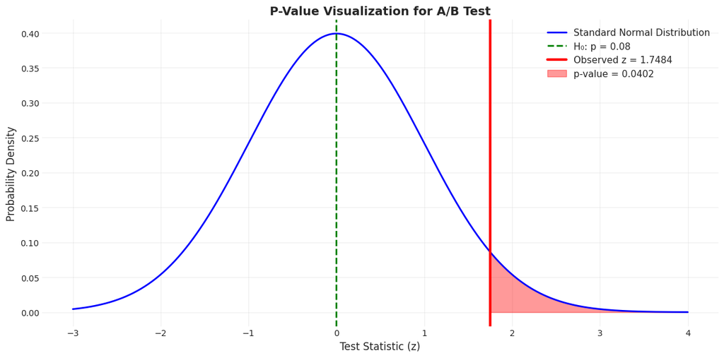

```python
# Visualize
x = np.linspace(-3, 4, 1000)
y = stats.norm.pdf(x)

plt.figure(figsize=(12, 6))
plt.plot(x, y, 'b-', linewidth=2, label='Standard Normal Distribution')
plt.axvline(0, color='green', linestyle='--', linewidth=2, label=f'H₀: p = {baseline_ctr}')
plt.axvline(z_stat, color='red', linestyle='-', linewidth=3, label=f'Observed z = {z_stat:.4f}')
plt.fill_between(x[x >= z_stat], y[x >= z_stat], alpha=0.4, color='red', label=f'p-value = {p_value_manual:.4f}')

plt.xlabel('Test Statistic (z)', fontsize=12)
plt.ylabel('Probability Density', fontsize=12)
plt.title('P-Value Visualization for A/B Test', fontsize=14, fontweight='bold')
plt.legend(fontsize=11)
plt.grid(True, alpha=0.3)
plt.tight_layout()
plt.show()
```

We can also calculate critical value for confidence level 0.05:

```python
# critical value
alpha = 0.05
critical_value = stats.norm.ppf(1 - alpha)

print(f"Significance level α = {alpha}")
print(f"Critical value = {critical_value:.4f}")
```

```
Significance level α = 0.05
Critical value = 1.6449
```

We can compare the observed $z$-statistic with the critical value:

$$z_{stat} = 1.7484 > z_{critical} = 1.6449$$

Henve, we can REJECT the null hypothesis.

5. **Step 5**: Make Decision

Given the siginificance level 0.05: $\text{p\_value} = 0.040193 < \alpha = 0.05$

Therefore, we REJECT the null hupothesis $H_0$. Moreover, the observed $z$-statistic is greater than the critical value

```python
if p_value_manual < alpha:
    print(f"✓ REJECT H₀ (p-value {p_value_manual:.4f} < α {alpha})")
    print(f"✓ The observed z-statistic {z_stat:.4f} > critical value {critical_value:.4f}")
    print()
    print("CONCLUSION: There IS statistically significant evidence that the")
    print("new algorithm performs better than the baseline (CTR > 8%).")
else:
    print(f"✗ FAIL TO REJECT H₀ (p-value {p_value_manual:.4f} ≥ α {alpha})")
    print(f"✗ The observed z-statistic {z_stat:.4f} ≤ critical value {critical_value:.4f}")
    print()
    print("CONCLUSION: There is NOT sufficient evidence that the new")
    print("algorithm performs better than the baseline.")
```

```
✓ REJECT H₀ (p-value 0.0402 < α 0.05)
✓ The observed z-statistic 1.7484 > critical value 1.6449

CONCLUSION: There IS statistically significant evidence that the
new algorithm performs better than the baseline (CTR > 8%).
```

Let's perform the test using Python implementations. We can consider two main options:

1. [`scipy.stats.binomtest`](https://docs.scipy.org/doc//scipy-1.16.2/reference/generated/scipy.stats.binomtest.html)
2. [`statsmodels.stats.proportion.proportions_ztest`](https://www.statsmodels.org/stable/generated/statsmodels.stats.proportion.proportions_ztest.html):

```python
# OPTION 1
p_value_binom = stats.binomtest(k=observed_clicks, n=n, p=baseline_ctr, alternative='greater')
print(f"P-value (binomial test): {p_value_binom.pvalue:.6f}")
```

```
P-value (binomial test): 0.048193
```

```python
# OPTION 2
z_stat_sm, p_value_sm = proportions_ztest(count=observed_clicks, nobs=n, value=baseline_ctr, alternative='larger', prop_var=p0)
print(f"Test statistic: {z_stat_sm:.4f}")
print(f"P-value: {p_value_sm:.6f}")
```

```
Test statistic: 1.7484
P-value: 0.040193
```

```python
print("COMPARISON")
print("-"*70)
print(f"{'Method':<31} {'Z-statistic':<15} {'P-value':<15}")
print("-"*70)
print(f"{'Manual calculation':<31} {z_stat:<15.4f} {p_value_manual:<15.6f}")
print(f"{'Statsmodels (proportions_ztest)':<31} {z_stat_sm:<15.4f} {p_value_sm:<15.6f}")
print(f"{'Scipy (binom_test)':<31} {'N/A':<15} {p_value_binom.pvalue:<15.6f}")
print("-"*70)
```

```
COMPARISON
----------------------------------------------------------------------
Method                          Z-statistic     P-value
----------------------------------------------------------------------
Manual calculation              1.7484          0.040193
Statsmodels (proportions_ztest) 1.7484          0.040193
Scipy (binom_test)              N/A             0.048193
----------------------------------------------------------------------
```

All the methods give us the same result and agree on the conclusion.

## Return to the Opening Challenge

*Remember:* Your model got 94.2% accuracy on 500 images. Boss says baseline is 95%. Is this difference significant?

```python
# Opening challenge solution
n_images = 500
correct_classifications = int(0.942 * n_images)  # 471
observed_accuracy = correct_classifications / n_images
baseline_accuracy = 0.95

print(f"Sample size: {n_images} images")
print(f"Correct classifications: {correct_classifications}")
print(f"Observed accuracy: {observed_accuracy:.3%}")
print(f"Baseline accuracy: {baseline_accuracy:.3%}")
```

```
Sample size: 500 images
Correct classifications: 471
Observed accuracy: 94.200%
Baseline accuracy: 95.000%
```

Let's formulate our hypotheses:

$$\begin{array}{ll}H_₀: p = 0.95 & \text{ (Your model has 95\% accuracy)}\\H_1: p < 0.95 & \text{ (Your model has less than 95\% accuracy)} \end{array}$$

- Test type: LEFT-TAILED
- $\alpha = 0.05$

```python
# Calculate test statistic
p0 = baseline_accuracy
se = np.sqrt(p0 * (1 - p0) / n_images)
z_stat = (observed_accuracy - p0) / se

print(f"Standard Error: {se:.6f}")
print(f"Test Statistic: z = {z_stat:.4f}")
```

```
Standard Error: 0.009747
Test Statistic: z = -0.8208
```

```python
# P-value
p_value = stats.norm.cdf(z_stat)  # left-tailed
print(f"P-value: {p_value:.4f}")
```

```
P-value: 0.2059
```

```python
# Decision
if p_value < 0.05:
    print("✗ REJECT H₀: Your model IS significantly worse than 95%")
    print("   Your boss was right to be concerned.")
else:
    print("✓ FAIL TO REJECT H₀: The difference is NOT statistically significant")
    print("   This could easily be due to random chance in test set selection.")
```

```
✓ FAIL TO REJECT H₀: The difference is NOT statistically significant
   This could easily be due to random chance in test set selection.
```

**COMMENT:** With only 500 images, the difference between 94.2% and 95% is NOT statistically significant at the 5% level.

**RECOMMENDATION:**

- Test on more images to reduce uncertainty
- Consider confidence intervals for accuracy
- Don't make deployment decisions based on small test sets

```python
# Show confidence interval
from statsmodels.stats.proportion import proportion_confint
ci_lower, ci_upper = proportion_confint(correct_classifications, n_images, alpha=0.05, method='wilson')
print(f"95% Confidence Interval for your model's accuracy:")
print(f"[{ci_lower:.3%}, {ci_upper:.3%}]")
```

```
95% Confidence Interval for your model's accuracy:
[91.794%, 95.932%]
```

Notice that 95% is WITHIN this interval. → We cannot rule out that your model truly has 95% accuracy.

## Python Reference

#### Python Reference Guide: Single-Sample Tests

##### ONE-SAMPLE T-TEST

```
from scipy import stats

# Test if sample mean differs from hypothesized value
t_stat, p_value = stats.ttest_1samp(data, popmean=0)

# One-sided tests (modify p-value)
p_value_right = p_value / 2 if t_stat > 0 else 1 - p_value/2
p_value_left = p_value / 2 if t_stat < 0 else 1 - p_value/2
```

##### ONE-SAMPLE Z-TEST (proportions)

```
from statsmodels.stats.proportion import proportions_ztest

# Test if proportion differs from hypothesized value
z_stat, p_value = proportions_ztest(count, nobs, value, alternative='two-sided')  # or 'larger', 'smaller'
```

##### CONFIDENCE INTERVALS

```
from scipy import stats

# For means (t-distribution)
ci = stats.t.interval(confidence=0.95, df=n-1, loc=sample_mean, scale=sem)

# For proportions
from statsmodels.stats.proportion import proportion_confint
ci_lower, ci_upper = proportion_confint(count, nobs, alpha=0.05, method='wilson')
```

##### POWER ANALYSIS

```
from statsmodels.stats.power import zt_ind_solve_power

# Calculate required sample size
n = zt_ind_solve_power(effect_size=0.5, alpha=0.05, power=0.8, alternative='two-sided')
```

## Common Mistakes

#### ⚠️ Common Mistakes in ML Hypothesis Testing

1. **P-hacking:** Running many tests and only reporting significant ones
   - Solution: Adjust for multiple comparisons (Bonferroni, FDR)
2. **Confusing statistical and practical significance:**
   - With huge datasets, tiny differences become "significant"
   - Always consider effect size and business impact!
3. **Ignoring assumptions:**
   - Tests assume random sampling, independence, distribution shape
   - Violations can lead to wrong conclusions
4. **Data snooping:** Looking at test data before choosing hypotheses
   - Invalidates p-values
   - Pre-register hypotheses or use separate validation sets
5. **Stopping tests early:** Checking p-values repeatedly and stopping when significant
   - Inflates Type I error rate
   - Use sequential testing methods or pre-specify stopping rules

## Key Takeaways

#### 📋 Key Takeaways

1. **Hypothesis Testing Framework:** Always start with H₀ (status quo) and only reject it when evidence is strong enough
2. **Two Types of Errors:** Type I (false positive) controlled by α, Type II (false negative) related to power
3. **Test Statistics:** Standardized measures of "surprise" - how many standard errors away from expected
4. **P-value:** NOT the probability H₀ is true; it's P(data this extreme | H₀ is true)
5. **Decision Rule:** Reject H₀ if p-value < α (or |test statistic| > critical value)

| Parameter | Mean | Mean | Mean | Variance | Proportion | Proportion |
| --- | --- | --- | --- | --- | --- | --- |
| **Sample Size** | $n < 30$ | $n \geq 30$ | Any | Any | Small ($np<10$) | Large ($np≥10$) |
| **$\sigma$ Known?** | No | No | Yes | N/A | N/A | N/A |
| **Test** | t-test | z-test (approx) | z-test | $\chi^2$ test | Binomial test | z-test for proportions |
| **Statistic** | $$t = \frac{\bar{X} -\mu_0}{s/\sqrt{n}}$$ | $$z = \frac{\bar{X} -\mu_0}{s/\sqrt{n}}$$ | $$z = \frac{\bar{X} -\mu_0}{\sigma/\sqrt{n}}$$ | $$\chi^2 = \frac{(n-1)s^2}{\sigma_0^2}$$ | Exact binomial | $$z = \frac{\hat{p} - p_0}{\sqrt{p_0(1-p_0)/n}}$$ |
| **Distribution** | $$t(n-1)$$ | $$N(0,1)$$ | $$N(0,1)$$ | $$\chi^2(n-1)$$ | Binomial | $$N(0,1)$$ |

## Useful Links

1. [Hypothesis Testing and the Null Hypothesis, Clearly Explained!!! by StatQuest](https://www.youtube.com/watch?v=0oc49DyA3hU)
2. [Alternative Hypothesis: Main Ideas!!! by StatQuest](https://www.youtube.com/watch?v=5koKb5B_YWo)
3. [p-values: What they are and how to interpret them by StatQuest](https://www.youtube.com/watch?v=vemZtEM63GY)
4. [How to calculate p-values by StatQuest](https://www.youtube.com/watch?v=JQc3yx0-Q9E)
5. [Using Bootstrapping to Calculate p-values!!! by StatQuest](https://www.youtube.com/watch?v=N4ZQQqyIf6k)
6. [p-hacking: What it is and how to avoid it! by StatQuest](https://www.youtube.com/watch?v=HDCOUXE3HMM)
7. [StatQuickie: Thresholds for Significance](https://www.youtube.com/watch?v=KEofcJ1tfkI)
8. [StatQuickie: Which t test to use](https://www.youtube.com/watch?v=nnBJeb_I-q8)
9. [StatQuest: One ot Two Tailed p-values](https://www.youtube.com/watch?v=bsZGt-caXO4)
10. [Quantile-Quantile Plots (QQ plots), Clearly Explained!!!](https://www.youtube.com/watch?v=okjYjClSjOg)
11. [Statistical Power, Clearly Explained!!! by StatQuest](https://www.youtube.com/watch?v=Rsc5znwR5FA)
12. [Power Analysis, Clearly Explained!!! by StatQuest](https://www.youtube.com/watch?v=VX_M3tIyiYk)